# Capstone

raj

June 19, 2017

## Bank Marketing Data Analysis

Below is the analysis of various factors (variables) influencing the criteria for an individual to signup for Term Deposit Account. The goal is to come up with a statistical model which helps in determining if the person would sign up for a term deposit account. Below is the summary of data available

```r
summary(bankdata)
```

```
##       age            job              marital           education
##  Min.   :19.00   Length:4521        Length:4521        Length:4521
##  1st Qu.:33.00   Class :character   Class :character   Class :character
##  Median :39.00   Mode  :character   Mode  :character   Mode  :character
##  Mean   :41.17
##  3rd Qu.:49.00
##  Max.   :87.00
##    default             balance        housing              loan
##  Length:4521        Min.   :-3313   Length:4521        Length:4521
##  Class :character   1st Qu.:   69   Class :character   Class :character
##  Mode  :character   Median :  444   Mode  :character   Mode  :character
##                     Mean   : 1423
##                     3rd Qu.: 1480
##                     Max.   :71188
##    contact               day           month              duration
##  Length:4521        Min.   : 1.00   Length:4521        Min.   :   4
##  Class :character   1st Qu.: 9.00   Class :character   1st Qu.: 104
##  Mode  :character   Median :16.00   Mode  :character   Median : 185
##                     Mean   :15.92                      Mean   : 264
##                     3rd Qu.:21.00                      3rd Qu.: 329
##                     Max.   :31.00                      Max.   :3025
##     campaign          pdays           previous         poutcome
##  Min.   : 1.000   Min.   : -1.00   Min.   : 0.0000   Length:4521
##  1st Qu.: 1.000   1st Qu.: -1.00   1st Qu.: 0.0000   Class :character
##  Median : 2.000   Median : -1.00   Median : 0.0000   Mode  :character
##  Mean   : 2.794   Mean   : 39.77   Mean   : 0.5426
##  3rd Qu.: 3.000   3rd Qu.: -1.00   3rd Qu.: 0.0000
##  Max.   :50.000   Max.   :871.00   Max.   :25.0000
##       y               bal_group       age_group         signup
##  Length:4521        Min.   :1.000   Min.   :1.000   Min.   :0.0000
##  Class :character   1st Qu.:2.000   1st Qu.:3.000   1st Qu.:0.0000
##  Mode  :character   Median :2.000   Median :3.000   Median :0.0000
##                     Mean   :1.866   Mean   :3.568   Mean   :0.1152
##                     3rd Qu.:2.000   3rd Qu.:4.000   3rd Qu.:0.0000
##                     Max.   :9.000   Max.   :8.000   Max.   :1.0000
##   housing_loan   personal_loan    duration_minutes
##  Min.   :0.000   Min.   :0.0000   Min.   : 0.000
##  1st Qu.:0.000   1st Qu.:0.0000   1st Qu.: 2.000
##  Median :1.000   Median :0.0000   Median : 3.000
##  Mean   :0.566   Mean   :0.1528   Mean   : 4.388
##  3rd Qu.:1.000   3rd Qu.:0.0000   3rd Qu.: 5.000
##  Max.   :1.000   Max.   :1.0000   Max.   :50.000
```

Various data wrangling activities has been done on the dataset to make it more suitable for plotting and analysis.

# Plots

Data has been collected and categorized based on the marital status of the individual. These are divided into 3 categories (single, married and divorced). Following is the Signup distribution comparison on Marital Status

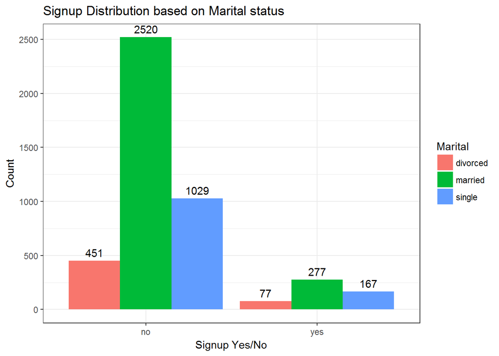

```r
#Distribution comparison based on Marital Status

ggplot(bankdata, aes(x =factor(y), fill = marital)) +
  geom_bar(position = "dodge") +
  geom_text(stat='count',aes(label=..count..),vjust=-0.5, position = position_dodge(width=0.9)) +
  labs(title = "Signup Distribution based on Marital status", x= "Signup Yes/No" , y= "Count", fill = "Marital") +
 theme_bw()
```

```r
  #scale_x_discrete(name ="Signup Yes/No")
#---------------------------------------------------------------------------------------
```

Signup comparison based on Marital status

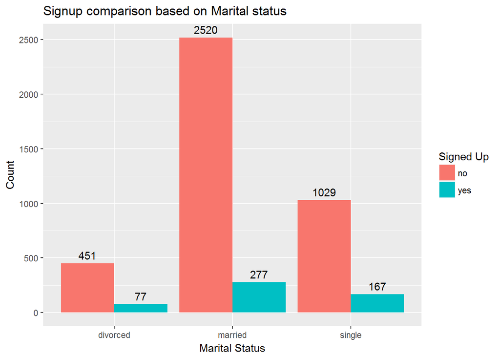

```r
#Distribution comparison based on Marital Status

ggplot(bankdata, aes(x =factor(marital), fill = y)) +
  geom_bar(position = "dodge") +
  geom_text(stat='count',aes(label=..count..),vjust=-0.5, position = position_dodge(width=0.9)) +
  labs(title = "Signup comparison based on Marital status", x= "Marital Status" , y= "Count", fill = "Signed Up")
```

```r
#---------------------------------------------------------------------------------------
```

Corr plots

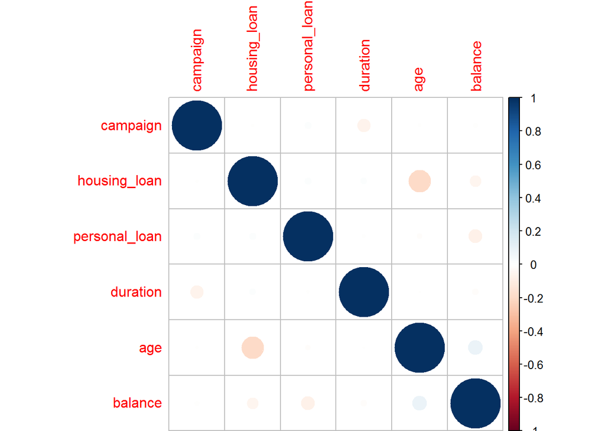

```r
#Corr plots

corrdata <-  subset(bankdata, select=c(age, balance, duration, campaign, housing_loan, personal_loan))
#View(corrdata)

M1 <- cor(corrdata)
corrplot(M1, method="circle", order ="hclust")
```

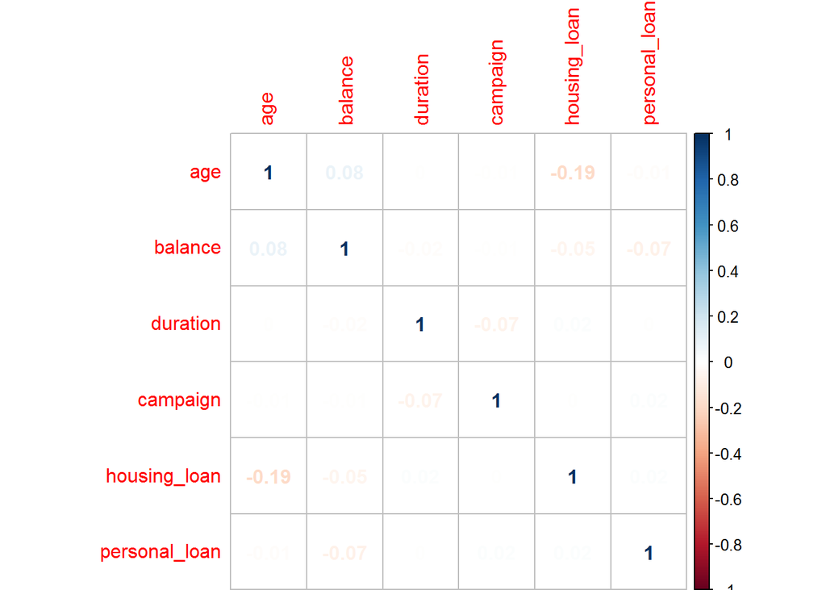

```r
M2 <- cor(corrdata)
corrplot(M2, method="number")
```

```r
#---------------------------------------------------------------------------------------
```

Below is the distribution who have signed up for Term Deposit based on matital status

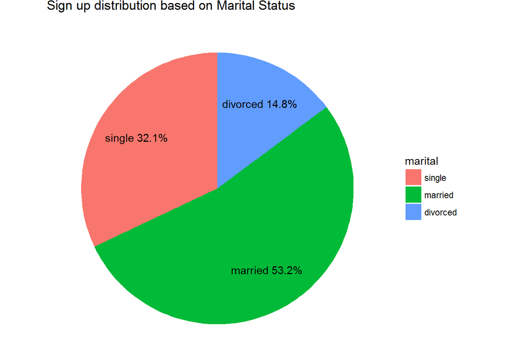

```r
#Sign up based on Marital Status

signup_only <- bankdata[bankdata$signup == 1, ]

signup_dist <- signup_only %>% group_by(marital) %>%
  summarise(no_rows = length(marital))


df1 <- signup_dist %>%
  # factor levels need to be the opposite order of the cumulative sum of the values
  mutate(marital = factor(marital, levels = c("single", "married", "divorced")),
         cumulative = cumsum(no_rows),
         midpoint = cumulative - no_rows / 2,
         label = paste0(marital, " ", round(no_rows / sum(no_rows) * 100, 1), "%"))


ggplot(df1, aes(x = 1, weight = no_rows, fill = marital)) +
  geom_bar(width = 1, position = "stack") +
  labs(title = "Sign up distribution based on Marital Status") +
  coord_polar(theta = "y") +
  geom_text(aes(x = 1.2, y = midpoint, label = label)) +
  #theme_classic()
  #theme_minimal()
  #theme_nothing()
  theme_void()
```

```r
#--------------------------------------------------------------------------------------
```

Below is the distribution who have signed up for Term Deposit based on Job category

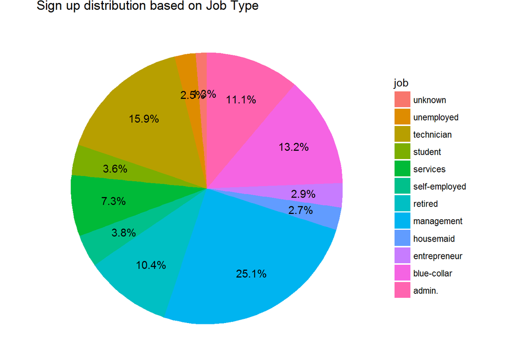

```r
job_dist <- signup_only %>% group_by(job) %>%
  summarise(no_rows = length(job))
#View(job_dist)
#View(signup_dist)

df2 <- job_dist %>%
  # factor levels need to be the opposite order of the cumulative sum of the values
  mutate(job = factor(job, levels = c("unknown","unemployed","technician","student","services","self-employed","retired","management","housemaid","entrepreneur","blue-collar","admin.")),
         cumulative = cumsum(no_rows),
         midpoint = cumulative - no_rows / 2,
         label = paste0("", " ", round(no_rows / sum(no_rows) * 100, 1), "%"))

#View(df2)

ggplot(df2, aes(x = 1, weight = no_rows, fill = job)) +
  geom_bar(width = 1, position = "stack") +
  labs(title = "Sign up distribution based on Job Type") +
  coord_polar(theta = "y") +
  geom_text(aes(x = 1.2, y = midpoint, label = label)) +
  #theme_classic()
  #theme_minimal()
  #theme_nothing()
  theme_void()
```

```r
#--------------------------------------------------------------------------------------
```

Below is the distribution who have signed up for Term Deposit based on education

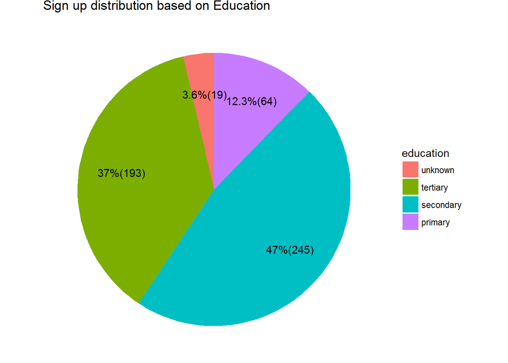

```r
edu_dist <- signup_only %>% group_by(education) %>%
  summarise(no_rows = length(education))
#View(edu_dist)
#View(signup_dist)

df3 <- edu_dist %>%
  # factor levels need to be the opposite order of the cumulative sum of the values
  mutate(education = factor(education, levels = c("unknown","tertiary","secondary","primary")),
  #       mutate(education = factor(education, levels = c("primary","secondary","tertiary","unknown")),
         cumulative = cumsum(no_rows),
         midpoint = cumulative - no_rows / 2,
         label = paste0("", " ", round(no_rows / sum(no_rows) * 100, 1), "%","(",no_rows,")")
)

#View(df3)
ggplot(df3, aes(x = 1, weight = no_rows, fill = education)) +
  geom_bar(width = 1, position = "stack") +
  labs(title = "Sign up distribution based on Education") +
  coord_polar(theta = "y") +
  geom_text(aes(x = 1.2, y = midpoint, label = label)) +
  #theme_classic()
  #theme_minimal()
  #theme_nothing()
  theme_void()
```

```r
#---------------------------------------------------------------------------------------
```

There is hardly any instances that signup is influenced by a factor where balance is more than 30000. Below is the plot showing signup based on call balance and call duration for the balances less than 30000

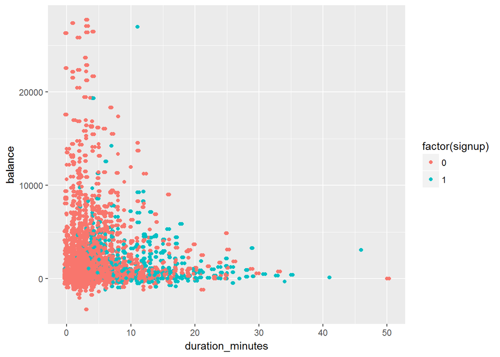

```r
balance_30000 <- bankdata[bankdata$balance < 30000, ]
ggplot(balance_30000, aes(y=balance, x=duration_minutes,col=factor(signup))) +
  geom_point() +
  geom_jitter()
```